# Mutational Signatures

C. Savonen for ALSF CCDL

2019

**Purpose:**

Calculate and plot mutational signatures for all samples using [COSMIC signatures](https://cancer.sanger.ac.uk/cosmic) and [Alexandrov et al, 2013](https://www.ncbi.nlm.nih.gov/pubmed/23945592) mutational signatures.

#### Usage

To run this from the command line, use:

```
Rscript -e "rmarkdown::render('analyses/mutational-signatures/mutational_signatures.Rmd',
                              clean = TRUE)"
```

*This assumes you are in the top directory of the repository.*

## Setup

#### Packages and functions

Import necessary functions.

```r
# Magrittr pipe
`%>%` <- dplyr::`%>%`

# Import specialized functions
source(file.path("util", "mut_sig_functions.R"))

# Load this library
library(deconstructSigs)
```

Set up directory paths.

```r
data_dir <- file.path("..", "..", "data")
results_dir <- "results"
plots_dir <- "plots"
figures_dir <- file.path("..", "..", "figures")
cosmic_plots <- file.path(plots_dir, "cosmic")
nature_plots <- file.path(plots_dir, "nature")
```

Make new directories for the results.

```r
if (!dir.exists(results_dir)) {
  dir.create(results_dir)
}
if (!dir.exists(cosmic_plots)) {
  dir.create(cosmic_plots, recursive = TRUE)
}
if (!dir.exists(nature_plots)) {
  dir.create(nature_plots, recursive = TRUE)
}
```

## Read in data

Read in the consensus MAF file.

```r
# Declare file path for consensus file
consensus_file <- file.path(data_dir, "pbta-snv-consensus-mutation.maf.tsv.gz")
```

Read in the consensus MAF file.

```r
# Read in the file
maf <- data.table::fread(consensus_file, data.table = FALSE)
```

```
|--------------------------------------------------|
|==================================================|
```

### Read in color palettes

Read in the histology color palette.

```r
histology_col_palette <- readr::read_tsv(
  file.path(figures_dir, "palettes", "histology_color_palette.tsv")
  ) %>%
  # We'll use deframe so we can use it as a recoding list
  tibble::deframe()
```

Set up gradient color palette for the bubble matrix plots.

```r
gradient_col_palette <- readr::read_tsv(
  file.path(figures_dir, "palettes", "gradient_color_palette.tsv")
  )
# Won't need NA color this time.
gradient_col_palette <- gradient_col_palette %>%
  dplyr::filter(color_names != "na_color")
```

Read in the metadata and set it up with the color palette.

```r
metadata_df <- readr::read_tsv(file.path(data_dir, "pbta-histologies.tsv")) %>%
  dplyr::rename(Tumor_Sample_Barcode = "Kids_First_Biospecimen_ID") %>%
  dplyr::select("Tumor_Sample_Barcode", "experimental_strategy", "short_histology") %>%
  # Easier to deal with NA short histologies if they are labeled something different
  dplyr::mutate(short_histology = as.character(tidyr::replace_na(short_histology, "none"))) %>%
  # Tack on the sample color using the short_histology column and a recode
  dplyr::mutate(sample_color = dplyr::recode(short_histology,
                                             !!!histology_col_palette))
```

[output not shown]

Read in this list so we can make sure we keep only primary tumors for the grouped bar plots.

```r
ind_samples <- readr::read_tsv(file.path(
  data_dir,
  "independent-specimens.wgswxs.primary.tsv"
))
```

Read in the WGS and WXS regions so they can be used for the Mb denominator.

```r
# Set up BED region files for TMB calculations
wgs_bed <- readr::read_tsv(file.path(data_dir, "WGS.hg38.strelka2.unpadded.bed"),
  col_names = FALSE
)
wxs_bed <- readr::read_tsv(file.path(data_dir, "WXS.hg38.100bp_padded.bed"),
  col_names = FALSE
)
# Calculate size of genome surveyed
# These files are BED files where the third column is the End position and
# the second column is the Start position.
# So End - Start gives the size of each range. Sum the gives the total size in bp.
wgs_size <- sum(wgs_bed[, 3] - wgs_bed[, 2])
wxs_size <- sum(wxs_bed[, 3] - wxs_bed[, 2])
```

## Set up data

Determine how many mutations we have per sample.

```r
mut_per_sample <- maf %>%
  dplyr::group_by(Tumor_Sample_Barcode) %>%
  dplyr::tally() %>%
  dplyr::arrange(n)

summary(mut_per_sample$n)
```

```
   Min. 1st Qu.  Median    Mean 3rd Qu.    Max.
      1      81     255    1309     802  139938
```

Graph this.

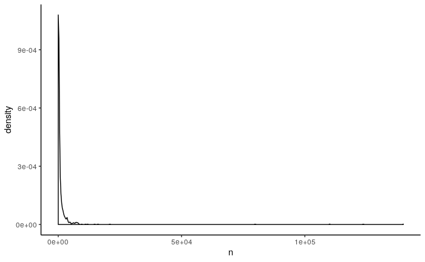

```r
ggplot2::ggplot(mut_per_sample, ggplot2::aes(x = n, geom = "density")) +
  ggplot2::geom_density() +
  ggplot2::theme_classic()
```

Make mutation data into `deconstructSigs` input format.

```r
# Convert to deconstructSigs input
sigs_input <- mut.to.sigs.input(
  mut.ref = maf,
  sample.id = "Tumor_Sample_Barcode",
  chr = "Chromosome",
  pos = "Start_Position",
  ref = "Reference_Allele",
  alt = "Allele",
  bsg = BSgenome.Hsapiens.UCSC.hg38::BSgenome.Hsapiens.UCSC.hg38
)
```

```
Some samples have fewer than 50 mutations:
  BS_4XPPZTGG, BS_3J4T2YYW, BS_541KKASA, BS_5FBN4PPQ, BS_WD7AQV83, BS_YEWX69X4, BS_QBZDQX7A, BS_T8C13KNH, BS_5TT6TT4K, BS_V2MDX7HG, BS_GRECE8Q9, BS_KKWQW01N, BS_MBYEK6HV, BS_78TQS4Y3, BS_8BM1WTGR, BS_M9YZK3SP, BS_QYWGB52C, BS_XDY9BYRK, BS_AR2BH0Z4, BS_WD37M8SD, BS_FBJ516WW, BS_6HE8H9HY, BS_KSHETTQC,…
```

Add total mutations per sample.

```r
# Count the total number of signature mutations for each sample
total_muts <- apply(sigs_input, 1, sum)
```

## Determine Signatures for COSMIC and Alexandrov et al, 2013

Get list of tumor sample ids.

```r
tumor_sample_ids <- maf %>%
  dplyr::filter(Tumor_Sample_Barcode %in% rownames(sigs_input)) %>%
  dplyr::distinct(Tumor_Sample_Barcode) %>%
  dplyr::pull(Tumor_Sample_Barcode)
```

Get [COSMIC signatures](https://cancer.sanger.ac.uk/cosmic) for each sample. This step will take some time.

```r
sample_sigs_cosmic <- lapply(tumor_sample_ids, function(sample_id) {
  # Determine the signatures contributing to the sample
  whichSignatures(
    tumor.ref = sigs_input,
    signatures.ref = signatures.cosmic,
    sample.id = sample_id,
    contexts.needed = TRUE
  )
})
# Bring along the names
names(sample_sigs_cosmic) <- tumor_sample_ids
```

Get [Alexandrov et al, 2013](https://www.ncbi.nlm.nih.gov/pubmed/23945592) signatures for each sample.

```r
sample_sigs_nature <- lapply(tumor_sample_ids, function(sample_id) {
  # Determine the signatures contributing to the sample
  whichSignatures(
    tumor.ref = sigs_input,
    signatures.ref = signatures.nature2013,
    sample.id = sample_id,
    contexts.needed = TRUE
  )
})
# Bring along the names
names(sample_sigs_nature) <- tumor_sample_ids
```

### COSMIC signature plots

```r
sample_mut_sig_plot(
  sample_sigs_cosmic,
  label = "cosmic",
  output_dir = file.path(cosmic_plots, "individual_mutation_sig")
)
```

### Alexandrov et al, 2013 signature plots

```r
sample_mut_sig_plot(
  sample_sigs_nature,
  label = "nature",
  output_dir = file.path(nature_plots, "individual_mutation_sig")
)
```

### Calculate the mutations per Mb for each signature

Do this for COSMIC mutation signatures.

```r
# Calculate mutations per signature
cosmic_sigs_df <- calc_mut_per_sig(
  sample_sigs_cosmic,
  muts_per_sample = total_muts,
  wgs_genome_size = wgs_size,
  wxs_exome_size = wxs_size,
  metadata = metadata_df
  )
# Write this to a file but drop the color column
cosmic_sigs_df %>%
  dplyr::select(-sample_color) %>%
  readr::write_tsv(file.path(results_dir, "cosmic_signatures_results.tsv"))

# Print out a preview
cosmic_sigs_df
```

| Tumor_Sample_Barcode | experimental_strategy | short_histology | sample_color | signature | num_mutations | genome_size | mut_per_mb |
| --- | --- | --- | --- | --- | --- | --- | --- |
| BS_1Q524P3B | WGS | HGAT | #406280 | Signature.1 | 580.9204224 | 3088286401 | 0.1881044524 |
| BS_BD4RQ1G0 | WGS | Schwannoma | #4d2636 | Signature.1 | 62.4807597 | 3088286401 | 0.0202315302 |
| BS_80X7AVCP | WGS | Embryonal Tumor | #304d26 | Signature.1 | 93.3159150 | 3088286401 | 0.0302160820 |
| BS_1JMTTKMK | WGS | Medulloblastoma | #7373e6 | Signature.1 | 57.5971178 | 3088286401 | 0.0186501866 |
| BS_9DM8H1RX | WGS | HGAT | #406280 | Signature.1 | 129.9435400 | 3088286401 | 0.0420762595 |
| BS_4XPPZTGG | WGS | Other | #cc0052 | Signature.1 | 0.0000000 | 3088286401 | 0.0000000000 |
| BS_3J4T2YYW | WGS | Medulloblastoma | #7373e6 | Signature.1 | 35.6877009 | 3088286401 | 0.0115558262 |
| BS_A1DV9T7G | WGS | Neurofibroma | #917399 | Signature.1 | 317.3797599 | 3088286401 | 0.1027688882 |
| BS_X7QJCVJB | WGS | Medulloblastoma | #7373e6 | Signature.1 | 346.0782835 | 3088286401 | 0.1120615897 |
| BS_Y3ETG5AE | WGS | LGAT | #00144d | Signature.1 | 48.9501095 | 3088286401 | 0.0158502493 |

[output cut: 990 more lines]

Do this for Alexandrov et al, 2013 mutation signatures.

```r
# Calculate mutations per signature
nature_sigs_df <- calc_mut_per_sig(
  sample_sigs_nature,
  muts_per_sample = total_muts,
  wgs_genome_size = wgs_size,
  wxs_exome_size = wxs_size,
  metadata = metadata_df
)
# Write this to a file but drop the color column
nature_sigs_df %>%
  dplyr::select(-sample_color) %>%
  readr::write_tsv(file.path(results_dir, "nature_signatures_results.tsv"))

# Print out a preview
nature_sigs_df
```

| Tumor_Sample_Barcode | experimental_strategy | short_histology | sample_color | signature | num_mutations | genome_size | mut_per_mb |
| --- | --- | --- | --- | --- | --- | --- | --- |
| BS_1Q524P3B | WGS | HGAT | #406280 | Signature.1A | 477.1823715 | 3088286401 | 0.1545136395 |
| BS_BD4RQ1G0 | WGS | Schwannoma | #4d2636 | Signature.1A | 62.8268240 | 3088286401 | 0.0203435873 |
| BS_80X7AVCP | WGS | Embryonal Tumor | #304d26 | Signature.1A | 87.6995779 | 3088286401 | 0.0283974886 |
| BS_1JMTTKMK | WGS | Medulloblastoma | #7373e6 | Signature.1A | 26.8420307 | 3088286401 | 0.0086915613 |
| BS_9DM8H1RX | WGS | HGAT | #406280 | Signature.1A | 133.5028766 | 3088286401 | 0.0432287875 |
| BS_4XPPZTGG | WGS | Other | #cc0052 | Signature.1A | 0.0000000 | 3088286401 | 0.0000000000 |
| BS_3J4T2YYW | WGS | Medulloblastoma | #7373e6 | Signature.1A | 34.8131347 | 3088286401 | 0.0112726380 |
| BS_A1DV9T7G | WGS | Neurofibroma | #917399 | Signature.1A | 0.0000000 | 3088286401 | 0.0000000000 |
| BS_X7QJCVJB | WGS | Medulloblastoma | #7373e6 | Signature.1A | 330.6465076 | 3088286401 | 0.1070647164 |
| BS_Y3ETG5AE | WGS | LGAT | #00144d | Signature.1A | 39.8948918 | 3088286401 | 0.0129181321 |

[output cut: 990 more lines]

## Mutation signature bubble matrix by histology groups

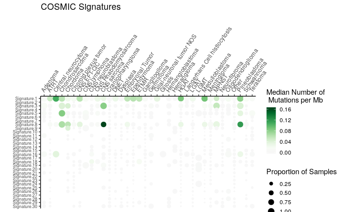

```r
bubble_matrix_plot(cosmic_sigs_df,
                   label = "COSMIC Signatures",
                   color_palette = gradient_col_palette$hex_codes
                   )
```

```r
ggplot2::ggsave(
  file.path(cosmic_plots, "bubble_matrix_cosmic_mutation_sig.png"),
  width = 30, height = 20, units = "cm")
```

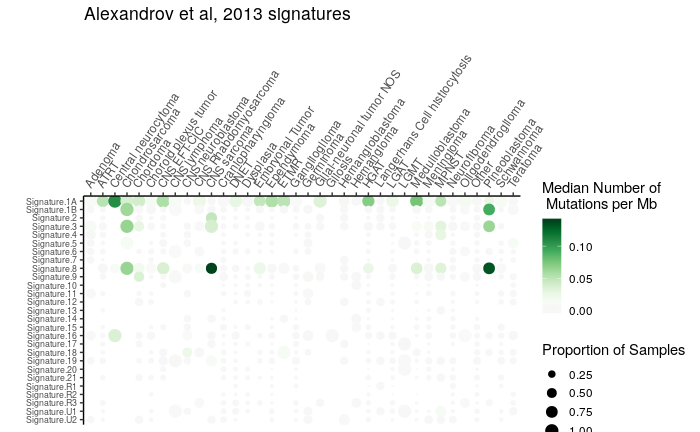

```r
bubble_matrix_plot(nature_sigs_df,
                   label = "Alexandrov et al, 2013 signatures",
                   color_palette = gradient_col_palette$hex_codes)
```

```r
ggplot2::ggsave(
  file.path(nature_plots, "bubble_matrix_nature_mutation_sig.png"),
  width = 30, height = 20, units = "cm")
```

## Mutation signature grouped bar plots for each histology group

We will make these plots for primary tumor samples only. Let’s make these for COSMIC mutation signatures first.

```r
# Keep only primary tumors
cosmic_sigs_primary <- cosmic_sigs_df %>%
  dplyr::filter(Tumor_Sample_Barcode %in% ind_samples$Kids_First_Biospecimen_ID)

# Make grouped bar plots
lapply(unique(cosmic_sigs_primary$short_histology),
  grouped_sig_barplot,
  sig_num_df = cosmic_sigs_primary,
  output_dir = file.path(cosmic_plots, "signature_grouped_barplots"),
  label = "cosmic"
)
```

Make these plots for Alexandrov et al, 2013 signatures.

```r
# Keep only primary tumors
nature_sigs_primary <- nature_sigs_df %>%
  dplyr::filter(Tumor_Sample_Barcode %in% ind_samples$Kids_First_Biospecimen_ID)

# Make grouped bar plots
lapply(unique(nature_sigs_primary$short_histology),
  grouped_sig_barplot,
  sig_num_df = nature_sigs_primary,
  output_dir = file.path(nature_plots, "signature_grouped_barplots"),
  label = "nature"
)
```